# 2018 GCMS pre-treatment

Eric R. Scott

2019-07-31

```r
knitr::opts_chunk$set(
    echo = TRUE
)
```

*Last compiled: 2019-09-05* # Packages

```r
library(tidyverse)
library(chemhelper)
library(here)
library(webchem)

#for outlier detection:
library(MVN)
library(HDoutliers)
library(ropls)

#resolve conflicts
map <- purrr::map
mvn <- MVN::mvn
```

# Workflow Overview

1. Tag 0’s as nondetects
2. Tag 0<Area<1000 as censored
3. Filter out known contaminants
4. Calculate RPA
5. Split data into samples and method blank
6. Subtract RPAs of method blank

This will give you sample data with 0s and possibly negative values for RPA and flags for nondetects and peaks that should be censored.

# Read in Data

## All the exported integration files

Need to be connected to network drive for this to work!

```r
Data.dir <- "/Volumes/as_rsch_orianslab_tea01$/IonAnalytics/IonAnalytics Projects/Shengzhou_2018/Data"

if(!dir.exists(Data.dir)) {
  stop("Gotta connect to the network drive!")
}

files <- dir(Data.dir,
             pattern = "Shengzhou_adj Integration Report.csv",
             full.names = TRUE, #adds full path
             recursive = TRUE) #drills down in directory structure

filenames <- str_extract(files, "(?<=/)[^/]+(?=/[^/]+$)")
# samples <- str_extract(filenames, "(?<=Hop_).+(?=\\.D)")
gc_tidy <- files %>%
  map(read_IA) %>%
  set_names(filenames) %>%
  bind_rows(.id = "filename") %>%
  rename(area = `Area [a.u.*s]`,
         rt = `R.Time [min.]`)
gc_tidy
```

| filename | No. | Type | Compound | Main Ion [M/Z] | rt | Expect. [min.] | St.Time [min.] | End Time [min.] | Height | area | QVal | Flags |
| --- | --- | --- | --- | --- | --- | --- | --- | --- | --- | --- | --- | --- |
| 072618_Longjing_Bag10 | 1 | NA | 1,4-Pentadiene | 67.1 | 0.000000 | 1.460000 | 0.000000 | 0.000000 | 0.0000 | 0.000000e+00 | 0.00000 | NA |
| 072618_Longjing_Bag10 | 2 | NA | 80 | 46.1 | 0.000000 | 1.572000 | 0.000000 | 0.000000 | 0.0000 | 0.000000e+00 | 0.00000 | NA |
| 072618_Longjing_Bag10 | 3 | NA | 2-Propenenitrile | 53.1 | 0.000000 | 1.603500 | 0.000000 | 0.000000 | 0.0000 | 0.000000e+00 | 0.00000 | NA |
| 072618_Longjing_Bag10 | 4 | NA | 41 | 43.1 | 0.000000 | 1.626270 | 0.000000 | 0.000000 | 0.0000 | 0.000000e+00 | 0.00000 | NA |
| 072618_Longjing_Bag10 | 5 | NA | 1,3-Cyclopentadiene | 66.1 | 0.000000 | 1.628000 | 0.000000 | 0.000000 | 0.0000 | 0.000000e+00 | 0.00000 | NA |
| 072618_Longjing_Bag10 | 6 | NA | 71 | 43.1 | 0.000000 | 1.649655 | 0.000000 | 0.000000 | 0.0000 | 0.000000e+00 | 0.00000 | NA |
| 072618_Longjing_Bag10 | 7 | NA | 1 | 42.1 | 0.000000 | 1.651604 | 0.000000 | 0.000000 | 0.0000 | 0.000000e+00 | 0.00000 | NA |
| 072618_Longjing_Bag10 | 8 | NA | 1-Propanol | 59.1 | 0.000000 | 1.698000 | 0.000000 | 0.000000 | 0.0000 | 0.000000e+00 | 0.00000 | NA |
| 072618_Longjing_Bag10 | 9 | NA | Cyclopentene | 67.1 | 0.000000 | 1.698000 | 0.000000 | 0.000000 | 0.0000 | 0.000000e+00 | 0.00000 | NA |
| 072618_Longjing_Bag10 | 10 | NA | Pentane, 2-methyl- | 43.1 | 0.000000 | 1.726000 | 0.000000 | 0.000000 | 0.0000 | 0.000000e+00 | 0.00000 | NA |

[output cut: 990 more lines]

## Alkane files

Read and wrangle

```r
alkanes1 <- read_IA("/Volumes/as_rsch_orianslab_tea01$/IonAnalytics/IonAnalytics Projects/Shengzhou_2018/Data/073018_alkanemix/Meth_073018_alkanemix Integration Report.csv")
alkanes_lj <-
  alkanes1 %>%
  slice(1:19) %>%  #that's enough I think.
  mutate(rt = ifelse(`R.Time [min.]` == 0, `Expect. [min.]`, `R.Time [min.]`)) %>%
  select(Compound, rt) %>%
  add_column(C_num = 6:24)


alkanes2 <- read_IA("/Volumes/as_rsch_orianslab_tea01$/IonAnalytics/IonAnalytics Projects/Shengzhou_2018/Data/082018_Alkane/Meth_073018_alkanemix Integration Report.csv")
alkanes_jgy <-
  alkanes2 %>%
  slice(1:19) %>%
  mutate(rt = ifelse(`R.Time [min.]` == 0, `Expect. [min.]`, `R.Time [min.]`)) %>%
  select(Compound, rt) %>%
  add_column(C_num = 6:24)
```

## Method file with CAS numbers

Even though there are technically two methods, they have the same compounds, so I should be able to get what I need from just one

```r
method <- read_IA("/Volumes/as_rsch_orianslab_tea01$/IonAnalytics/IonAnalytics Projects/Shengzhou_2018/Methods/Shengzhou_adj_JGY/Shengzhou_adj Compound References.csv")
```

Merge with data

```r
CASs <-
  method %>%
  select(Compound, CAS) %>%
  mutate(CAS = str_remove_all(CAS, "-")) %>%
  mutate(CAS = as.cas(CAS)) %>%
  #try to catch all the unknowns
  mutate(CAS = ifelse(str_detect(Compound, "^\\d+$") | str_detect(Compound, "DCSE"), NA, CAS))
```

[output not shown]

[output cut: 89 more lines]

[output not shown]

```r
# CASs %>% filter(Compound == "1,4-Pentadiene")

gc_tidy <-
  left_join(gc_tidy, CASs) %>% select(filename, No., Type, Compound, CAS, everything())
```

## Extract cultivar and sample name from filename

I think jinguanyin blank20 is actually not a blank

```r
gc_tidy <-
  gc_tidy %>%
  mutate(filename = str_remove(filename, ".D$")) %>% # for some reason one file has a .D at the end.
  mutate(filename = str_replace(filename, "Blank20", "Bag20")) %>% #pretty sure it's not a blank
  mutate(cultivar = case_when(str_detect(filename, "Longjing") ~ "L",
                              str_detect(filename, "Jin") ~ "J",
                              TRUE ~ as.character(NA)), #shouldn't be any NAs, but just in case
         plant_num = as.character(as.integer(str_extract(filename, "\\d+$"))), #blanks will be NA
         sample = paste0(cultivar, plant_num)) %>%
  select(filename, cultivar, plant_num, sample, everything())
```

# Tag non-detects and to-be-censored

```r
gc_tidy <-
  gc_tidy %>%
  mutate(ND = area == 0)
```

# Remove known contaminants and problematic peaks

Contaminants:

- Propanoic acid, 2-methyl-, 1-(1, 1-dimethylethyl)-2methyl-1, 3-propanediyl ester (from nitrile gloves)
- Toluene (very large peak, seems unlikely that it is a natural product)

These chlorinated compounds are likely pesticides:

- Benzaldehyde, 2,6-dichloro-
- Benzene, chloro-

```r
contaminants <- c("Propanoic acid, 2-methyl-, 1-(1,1-dimethylethyl)-2-methyl-1,3-propanediyl ester",
                  "Toluene",
                  "Benzyl chloride",
                  "Benzene, chloro-",
                  "Benzaldehyde, 2,6-dichloro-",
                  "141")

gc_tidy.1 <-
  gc_tidy %>%
  filter(!Compound %in% contaminants) %>%
  filter(No. > 91)
```

# Calculate RPA

Two files have abnormally low values for the peak area of the internal standard. I’ll remove those two samples.

I also noticed here that JGY and LJ cultivars internal standard peak areas are more than an order of magnitude different. I probably should be cautios about comparing cultivars

```r
#extract napthalene D8 area
gc_IS <-
  gc_tidy.1 %>%
  filter(Compound == "Naphthalene-D8") %>%
  rename(IS = area) %>%
  select(filename, cultivar, IS)

weirdos <- gc_IS %>% filter(IS < 100000)
# JGY 11 and JGY 4


#join with gc.tidy and mutate to calculate RPA
gc_tidy.2 <- full_join(gc_tidy.1, gc_IS)
gc_tidy.2 <- gc_tidy.2 %>%
  mutate(RPA = area/IS) %>%
  #don't need Naphtalene-D8 anymore
  filter(Compound != "Naphthalene-D8") %>%
  #remove weird samples
  filter(!filename %in% weirdos$filename)
```

# Field blank subtraction

I have two field blanks, one for each cultivar

```r
gc_tidy.3 <-
  gc_tidy.2 %>%
  #split by cultivar
  group_by(cultivar) %>%
  group_split() %>%
  # for each cultivar extract the blanks and join them to the data minus the blanks
  purrr::map(~{
    blank <- filter(., str_detect(filename, "[b,B]lank")) %>%
      rename(background = RPA) %>%
      select(Compound, background)
    gc <- filter(., !str_detect(filename, "[b,B]lank"))
    left_join(gc, blank)
  }) %>%
  # recombine cultivars
  bind_rows()
```

I’m literally subtracting the blank. The alternative is Nicole’s method: if RPA > background then keep it as is, if RPA <= background, set to zero.

```r
gc_tidy.4 <- gc_tidy.3 %>%
  mutate(RPA = RPA-background)
gc_tidy.4
```

| filename | cultivar | plant_num | sample | No. | Type | Compound | CAS | Main Ion [M/Z] | rt | Expect. [min.] | St.Time [min.] | End Time [min.] | Height | area | QVal | Flags | ND | IS | RPA | background |
| --- | --- | --- | --- | --- | --- | --- | --- | --- | --- | --- | --- | --- | --- | --- | --- | --- | --- | --- | --- | --- |
| 081618_JinGuanYin_Bag1 | J | 1 | J1 | 92 | NA | Furan, tetrahydro-2,2,5,5-tetramethyl- | 15045-43-9 | 113.1 | 0.000000 | 3.507823 | 0.000000 | 0.000000 | 0.0000 | 0.0000 | 0.00000 | NA | TRUE | 1454297 | 0.000000e+00 | 0.000000e+00 |
| 081618_JinGuanYin_Bag1 | J | 1 | J1 | 93 | NA | 2-Butenal, 2-methyl- | 497-03-0 | 84.1 | 0.000000 | 3.551139 | 0.000000 | 0.000000 | 0.0000 | 0.0000 | 0.00000 | NA | TRUE | 1454297 | 0.000000e+00 | 0.000000e+00 |
| 081618_JinGuanYin_Bag1 | J | 1 | J1 | 94 | NA | Pentane, 2,3,4-trimethyl- | 565-75-3 | 43.1 | 0.000000 | 3.551139 | 0.000000 | 0.000000 | 0.0000 | 0.0000 | 0.00000 | NA | TRUE | 1454297 | 0.000000e+00 | 0.000000e+00 |
| 081618_JinGuanYin_Bag1 | J | 1 | J1 | 95 | NA | 1-Heptene, 4-methyl- | 13151-05-8 | 70.1 | 0.000000 | 3.551139 | 0.000000 | 0.000000 | 0.0000 | 0.0000 | 0.00000 | NA | TRUE | 1454297 | 0.000000e+00 | 0.000000e+00 |
| 081618_JinGuanYin_Bag1 | J | 1 | J1 | 96 | NA | 22 (DCSE) | NA | 74.0 | 3.593067 | 3.607924 | 3.548733 | 3.655900 | 9456.7070 | 18088.3198 | 99.45421 | NA | FALSE | 1454297 | 1.243784e-02 | 0.000000e+00 |
| 081618_JinGuanYin_Bag1 | J | 1 | J1 | 97 | NA | Heptane, 4-methyl- | 589-53-7 | 71.1 | 3.718717 | 3.616113 | 3.678067 | 3.722417 | 748.5839 | 1154.2719 | 96.02460 | Q | FALSE | 1454297 | 7.936973e-04 | 0.000000e+00 |
| 081618_JinGuanYin_Bag1 | J | 1 | J1 | 99 | NA | 1-Pentanol | 71-41-0 | 55.1 | 0.000000 | 3.637771 | 0.000000 | 0.000000 | 0.0000 | 0.0000 | 0.00000 | D | TRUE | 1454297 | 0.000000e+00 | 0.000000e+00 |
| 081618_JinGuanYin_Bag1 | J | 1 | J1 | 100 | TRUE | Propyl aldoxime, 2-methyl-, anti- | 5775-73-5 | 70.0 | 0.000000 | 3.681087 | 0.000000 | 0.000000 | 0.0000 | 0.0000 | 0.00000 | NA | TRUE | 1454297 | 0.000000e+00 | 0.000000e+00 |
| 081618_JinGuanYin_Bag1 | J | 1 | J1 | 101 | NA | 63 | NA | 43.1 | 0.000000 | 3.704234 | 0.000000 | 0.000000 | 0.0000 | 0.0000 | 0.00000 | NA | TRUE | 1454297 | 0.000000e+00 | 0.000000e+00 |
| 081618_JinGuanYin_Bag1 | J | 1 | J1 | 102 | NA | Heptane, 3-methyl- | 589-81-1 | 57.1 | 0.000000 | 3.746061 | 0.000000 | 0.000000 | 0.0000 | 0.0000 | 0.00000 | NA | TRUE | 1454297 | 0.000000e+00 | 0.000000e+00 |

[output cut: 990 more lines]

# Read in leafhopper density and damage data and join

```r
treatments <- read_rds(here('data', 'cleaned', '2018_treatment_data.rds'))
gc_tidy.5 <- left_join(gc_tidy.4, treatments)
```

# Calculate Retention Indices

```r
gc_tidy.6 <-
  gc_tidy.5 %>%
  mutate(ri = case_when(cultivar == "J" ~ calc_RI(rt, alkanes_jgy$rt, alkanes_jgy$C_num),
                        cultivar == "L" ~ calc_RI(rt, alkanes_lj$rt, alkanes_lj$C_num)))
```

# Deal with non-detects, censored peaks, and other zeros and negative values

Nondetects were zeros to begin with, not found by IonAnalytics at all. I’m not censoring peaks. However, if RPA <=0 because of non-detect or blank-subtraction, I’ll set RPA to a small number (100/IS). This will be useful for log-transforming data since log(0) = -inf. I also add a “present” column that will be useful for getting compound counts and such later on.

Also set Q-values of compounds not found to NA

```r
gc_tidy.7 <-
  gc_tidy.6 %>%
  mutate(RPA = case_when(ND       ~ 100/IS,
                         RPA <= 0 ~ 100/IS, #if after background subtraction peak areas < 500
                         TRUE     ~ RPA),
         present = case_when(ND      ~ FALSE,
                             RPA <=0 ~ FALSE,
                             TRUE    ~ TRUE)) %>%
  mutate(QVal = ifelse(present, QVal, NA)) %>%
  select(sample, cultivar, density_start, density_end, mean_percent_damage, twister_damage, No., Compound, CAS, RPA, QVal, rt, ri, present)

#How many compounds detected in each sample?
gc_tidy.7 %>%
  group_by(sample) %>%
  summarize(num_compounds = sum(present))
```

| sample | num_compounds |
| --- | --- |
| J1 | 227 |
| J10 | 227 |
| J13 | 233 |
| J14 | 231 |
| J15 | 232 |
| J16 | 229 |
| J17 | 203 |
| J18 | 234 |
| J19 | 200 |
| J2 | 219 |

[output cut: 29 more lines]

Preserve zeros for distance-based analyses:

```r
gc_zeroes <-
  gc_tidy.7 %>%
  mutate(RPA = ifelse(present, RPA, 0))
```

# Remove rare peaks

```r
gc_tidy.final <-
  gc_tidy.7 %>%
  group_by(Compound) %>% #for each compound...
  filter(sum(present) >= 5)
gc_tidy.final %>% ungroup() %>% count(sample) #326 compounds
```

| sample | n |
| --- | --- |
| J1 | 314 |
| J10 | 314 |
| J13 | 314 |
| J14 | 314 |
| J15 | 314 |
| J16 | 314 |
| J17 | 314 |
| J18 | 314 |
| J19 | 314 |
| J2 | 314 |

[output cut: 29 more lines]

```r
gc_zeroes.final <-
  gc_zeroes %>%
  group_by(Compound) %>%
  filter(sum(present) >= 5)
gc_zeroes.final %>% ungroup() %>% count(sample) #just checking that it's the same
```

| sample | n |
| --- | --- |
| J1 | 314 |
| J10 | 314 |
| J13 | 314 |
| J14 | 314 |
| J15 | 314 |
| J16 | 314 |
| J17 | 314 |
| J18 | 314 |
| J19 | 314 |
| J2 | 314 |

[output cut: 29 more lines]

# Check for compounds with low average Q-value

I really don’t super trust the Q-value anymore, but I think I’ll go ahead and filter out anything with a Q-value less than 90.

```r
lowQs <-
  gc_tidy.final %>%
  group_by(Compound) %>%
  summarize(meanQ = mean(QVal, na.rm = TRUE)) %>%
  arrange(meanQ) %>%
  filter(meanQ <= 90) %>%
  pull(Compound)

gc_tidy.final <- gc_tidy.final %>% filter(!Compound %in% lowQs)
gc_zeroes.final <- gc_zeroes.final %>% filter(!Compound %in% lowQs)
```

# Create wide dataframe for multivariate analysis

Unfortunately changes column order to alphabetical. This is fixed in `tidyr` 1.0 with the `pivot_wider()` function, but I don’t think its so important that I need to use a development version of a package.

```r
gc_wide <-
  gc_tidy.final %>%
  select(-rt, -ri, -No., -present, -CAS, -QVal) %>%
  spread(key = Compound, value = RPA)

gc_wide.zeroes <-
  gc_zeroes.final %>%
  ungroup %>%
  select(-rt, -ri, -No., -present, -CAS, -QVal) %>%
  spread(key = Compound, value = RPA)
```

# Outlier detection

## Multivariate normality

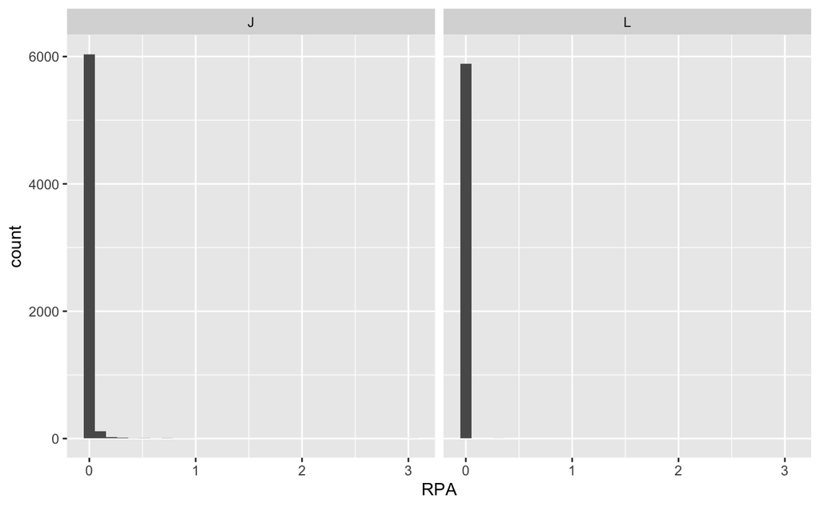

```r
gc_tidy.final %>%
  ggplot(aes(RPA)) + geom_histogram() + facet_wrap(~cultivar)
```

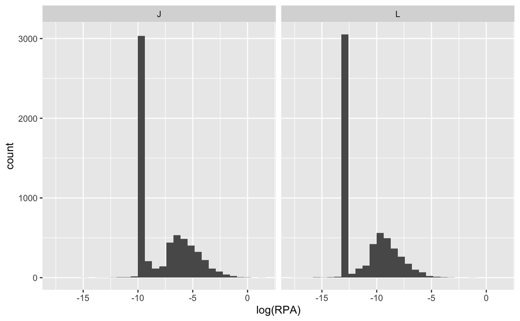

```r
gc_tidy.final %>%
  ggplot(aes(log(RPA))) + geom_histogram() +facet_wrap(~cultivar)
```

This may change once the data is finalized.

```r
metavars <- c("sample", "cultivar", "density_start", "density_end", "mean_percent_damage", "twister_damage")
```

```r
# This code seems to hang.
# test <-
#   gc_tidy.final %>%
#   ungroup() %>%
#   select(-rt, -ri, -No., -present, -CAS) %>%
#   spread(key = Compound, value = RPA) %>%
#   select(-metavars) %>%
#   # mutate_all(~.*1000) %>%
#   mvn(mvnTest = "mardia",
#       transform = "log",
#       multivariatePlot = "qq",
#       scale = TRUE)
# test
```

## Multivariate outlier detection

Using Leland Wilkinson’s algorithm from `HDoutliers`

```r
out <- HDoutliers(select(gc_wide, -metavars) , alpha = 0.1)
gc_wide[out, ]
```

| sample | cultivar | density_start | density_end | mean_percent_damage | twister_damage | .tau.-Cadinol | 1-(4-tert-Butylphenyl)propan-2-one | 1-Hexanol, 2-ethyl- | 1-Nonanol | 1-Octanol | 1-Octanol, 3,7-dimethyl- | 1,1'-Biphenyl, 3,4-diethyl- | 1,2,3-Trimethylbenzene | 1,2,4-Trimethylbenzene | 1,4-Dimethylnaphthalene | 10,18-Bisnorabieta-8,11,13-triene | 101 | 102 | 103 | 107 | 11 (DCSE) | 115 | 117 | 118 | 120 | 127 | 13 (DCSE) | 145 | 148 | … |
| --- | --- | --- | --- | --- | --- | --- | --- | --- | --- | --- | --- | --- | --- | --- | --- | --- | --- | --- | --- | --- | --- | --- | --- | --- | --- | --- | --- | --- | --- | --- |

```r
#after log transformation
out2 <- HDoutliers(select(gc_wide, -metavars) %>% mutate_all(log), alpha = 0.1)
gc_wide[out2, ]
```

| sample | cultivar | density_start | density_end | mean_percent_damage | twister_damage | .tau.-Cadinol | 1-(4-tert-Butylphenyl)propan-2-one | 1-Hexanol, 2-ethyl- | 1-Nonanol | 1-Octanol | 1-Octanol, 3,7-dimethyl- | 1,1'-Biphenyl, 3,4-diethyl- | 1,2,3-Trimethylbenzene | 1,2,4-Trimethylbenzene | 1,4-Dimethylnaphthalene | 10,18-Bisnorabieta-8,11,13-triene | 101 | 102 | 103 | 107 | 11 (DCSE) | 115 | 117 | 118 | 120 | 127 | 13 (DCSE) | 145 | 148 | … |
| --- | --- | --- | --- | --- | --- | --- | --- | --- | --- | --- | --- | --- | --- | --- | --- | --- | --- | --- | --- | --- | --- | --- | --- | --- | --- | --- | --- | --- | --- | --- |

No outliers detected

## With PCA

```r
pca <- opls(select(gc_wide, -metavars)%>% mutate_all(log) , plotL = FALSE, predI = 2)
```

```
'plotL' argument is deprecated; use 'fig.pdfC' instead
```

```
PCA
39 samples x 310 variables
standard scaling of predictors
```

|  | R2X(cum) | pre | ort |
| --- | --- | --- | --- |
| Total | 0.617 | 2 | 0 |

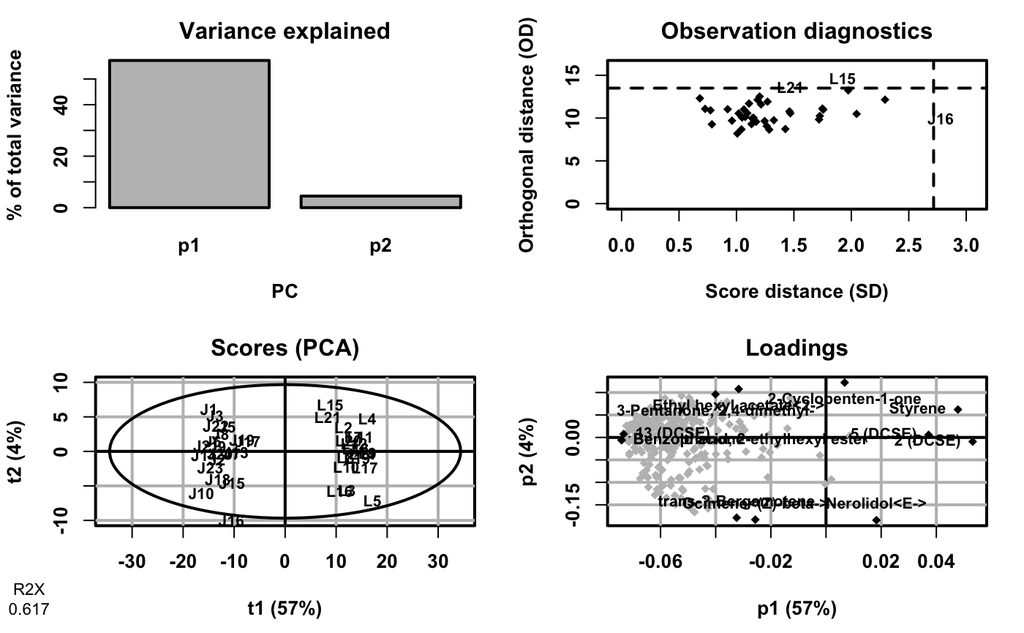

```r
plot(pca, parLabVc = gc_wide$sample)
```

L15 and J16 are maybe an extreme values, but not worth removing.

# Write to file

I think all I’m going to need is the tidy version with the `present` column and the wide version. I can do any data transformations in the analysis script.

```r
write_rds(gc_tidy.final, here('data', 'cleaned', '2018_gcms_tidy.rds'))
write_rds(gc_wide, here('data', 'cleaned', '2018_gcms_wide.rds'))
write_rds(gc_wide.zeroes, here("data", "cleaned", "2018_gcms_zeroes.rds"))
```